# Allgemeine Aufgaben Gruppe 11

Alik Aylarov (389982), Ange Adissin (455022), Ida Kossatz (476046), Minh Ngoc Hoang (393166), Anna Vera Wagner (453684)

17-03-2024

Vorbereiten der Programmierumgebung um alle gewünschten Imports, Operationen und Anpassungen vornehmen zu können., wird das dplyr Package installiert und die Packages lubridate, ggplot2, knitr und stringr geladen.

Überprüfen und installieren von benötigten Paketen

```r
if (!require(install.load)) {
  install.packages("install.load")
}
if (!require(dplyr)) {
  install.packages("dplyr")
}
if (!require(lubridate)) {
  install.packages("lubridate")
}
```

```r
if (!require(ggplot2)) {
  install.packages("ggplot2")
}
if (!require(stringr)) {
  install.packages("stringr")
}
if (!require(knitr)) {
  install.packages("knitr")
}
if (!require(magrittr)) {
  install.packages("magrittr")
}
```

## Aufgabe 1

Laden der erforderlichen Pakete

```r
library(dplyr)
library(lubridate)
```

Zunächst müssen zwei CSV-Dateien eingelesen werden, um sie für weitere Berechnungen zu einem Datenrahmen zusammenzufassen.

```r
komponente_k7 <- read.csv("Komponente_K7.csv", sep=";")
logistikverzug_k7 <- read.csv("Logistikverzug_K7.csv", sep=";")
```

Zusammenführung der Dateien anhand der IDNummer

```r
gesamt_df <- merge(komponente_k7, logistikverzug_k7, by.x="IDNummer", by.y="IDNummer")
```

Datumsumwandlung für die Berechnung des Logistikverzugs

```r
gesamt_df$Produktionsdatum <- as.Date(gesamt_df$Produktionsdatum, format = "%Y-%m-%d")
gesamt_df$Wareneingang <- as.Date(gesamt_df$Wareneingang, format = "%d.%m.%Y")
```

Berechnung des Logistikverzugs in Tagen (unter Berücksichtigung eines weiteren Tags für Versandvorbereitung). Angenommen wurde, dass vom Zeitpunkt der Produktion bis zur Übergabe der Waren an die Logistik ein Tag vergeht und ein weiterer Tag für die Vorbereitung der Waren für den Versand benötigt wird. Um den Versandtag zu berechnen, müssen also zwei Tage zum Tag der Produktion der Waren hinzugezählt werden.

```r
gesamt_df <- gesamt_df %>%
  mutate(Logistikverzug = as.numeric(difftime(Wareneingang, Produktionsdatum + days(2)), units = "days"))
```

## b. Mindestens/Höchstens vergangene Zeit zwischen Warenausgang und Wareneingang

### Minimaler und Maximaler Zeitunterschied zwischen Warenausgang und Wareneingang sind jeweils 0 und 11 Tage

Minimaler Zeitunterschied zwischen Warenausgang und Wareneingang

```r
min_zeit <- min(gesamt_df$Logistikverzug, na.rm = TRUE)
```

Maximaler Zeitunterschied zwischen Warenausgang und Wareneingang

```r
max_zeit <- max(gesamt_df$Logistikverzug, na.rm = TRUE)
```

Ausgabe der Ergebnisse

```r
cat("Minimale Zeitunterschied zwischen Warenausgang und Wareneingang:", min_zeit, "Tage\n")
```

```
## Minimale Zeitunterschied zwischen Warenausgang und Wareneingang: 0 Tage
```

```r
cat("Maximale Zeitunterschied zwischen Warenausgang und Wareneingang:", max_zeit, "Tage\n")
```

```
## Maximale Zeitunterschied zwischen Warenausgang und Wareneingang: 11 Tage
```

## c. Mittelwertsberechnung

### Der Mittelwert des Logistikverzugs ist 3.080437 Tage

Mittelwert des Logistikverzugs berechnen

```r
mittelwert_logistikverzug <- mean(gesamt_df$Logistikverzug, na.rm = TRUE)
```

Ausgabe des Mittelwerts

```r
cat("Mittelwert des Logistikverzugs:", mittelwert_logistikverzug, "Tage\n")
```

```
## Mittelwert des Logistikverzugs: 3.080437 Tage
```

Histogramm des Logistikverzugs erstellen

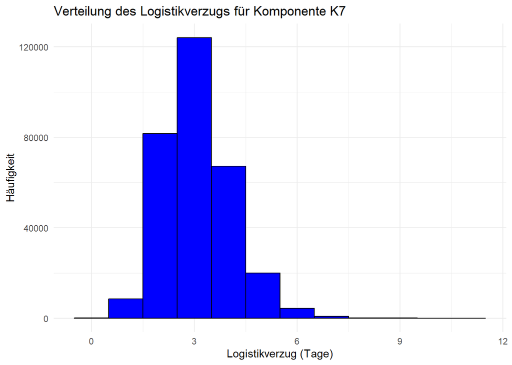

```r
# Laden des erforderlichen Pakets
library(ggplot2)

ggplot(gesamt_df, aes(x=Logistikverzug)) +
  geom_histogram(binwidth=1, fill="blue", color="black") +
  theme_minimal() +
  labs(title="Verteilung des Logistikverzugs für Komponente K7",
       x="Logistikverzug (Tage)",
       y="Häufigkeit")
```

Erstellen von Variablen für Jahr und Quartal

```r
gesamt_df$Jahr <- year(as.Date(gesamt_df$Wareneingang))  # Jahr aus dem Wareneingangsdatum extrahieren
gesamt_df$Quartal <- quarter(as.Date(gesamt_df$Wareneingang))  # Quartal aus dem Wareneingangsdatum extrahieren
```

Berechnung der durchschnittlichen Verzögerung pro Jahr und Quartal

```r
jahr_quartal_zusammenfassung <- gesamt_df %>%
  group_by(Jahr, Quartal) %>%
  summarise(Durchschnittliche_Verzögerung = mean(Logistikverzug, na.rm = TRUE),
            .groups = "drop")
```

Berechnung der Gesamtdurchschnittswerte pro Quartal

```r
gesamt_mittelwerte <- jahr_quartal_zusammenfassung %>%
  group_by(Quartal) %>%
  summarise(Gesamtdurchschnitt = mean(Durchschnittliche_Verzögerung))
```

Erstellen des Diagramms

```r
p <- ggplot(jahr_quartal_zusammenfassung, aes(x = Jahr, y = Durchschnittliche_Verzögerung, group = Quartal, color = factor(Quartal))) +
  geom_line(linewidth = 1.5) +  # Verwenden von linewidth anstelle von size
  geom_point(size = 3) +  # Beibehalten der Punktegröße
  theme_minimal() +
  theme(axis.text.x = element_text(angle = 90, hjust = 1)) +
  labs(title = "Durchschnittliche Logistikverzögerung pro Quartal und Jahr für Komponente K7",
       x = "Jahr",
       y = "Durchschnittliche Verzögerung (Tage)",
       color = "Quartal")
```

Hinzufügen von Annotationen mit den Gesamtdurchschnittswerten

```r
for(i in 1:nrow(gesamt_mittelwerte)) {
  p <- p + annotate("text", x = max(jahr_quartal_zusammenfassung$Jahr), y = gesamt_mittelwerte$Gesamtdurchschnitt[i],
                    label = paste("Q", gesamt_mittelwerte$Quartal[i], ":", round(gesamt_mittelwerte$Gesamtdurchschnitt[i], 2), "Tage"),
                    hjust = 1, vjust = -0.5)
}
```

Anzeigen des Diagramms

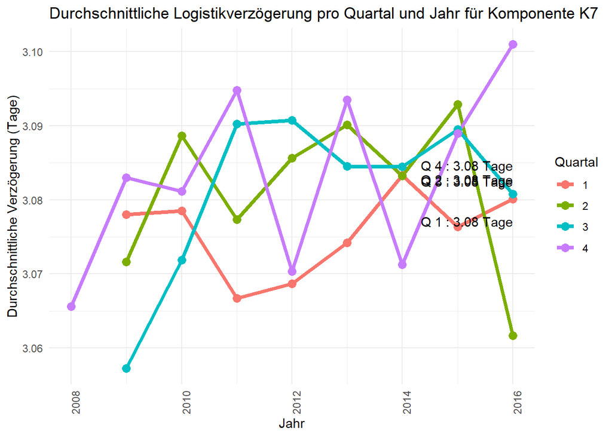

```r
print(p)
```

## Aufgabe 2

### Gründe Daten in separaten Dateien abzulegen und nicht alles in einer riesigen Tabelle zu speichern

### - Modularität und Skalierbarkeit

Durch die Aufteilung der Daten in separate Dateien nach logischen Einheiten, wie z.B. Tabellen für verschiedene Entitäten oder Datenquellen, wird die Modularität erhöht. Dies erleichtert die Verwaltung, Aktualisierung und Skalierung der Datenbank, da Änderungen an einer Datei keine Auswirkungen auf andere haben.

### - Effizienz bei der Datenverwaltung

Separate Dateien erleichtern das Organisieren und Verwalten von Daten, da jeder Datensatz oder jede Entität in einer eigenen Datei gespeichert ist. Dadurch wird die Datenverwaltung effizienter und Fehler bei der Datenmanipulation werden minimiert.

### - Verbesserte Datenintegrität

Die Verwendung separater Dateien trägt zur Datenintegrität bei, da Daten in logisch zusammenhängenden Gruppen organisiert sind. Dies erleichtert die Durchsetzung von Integritätsregeln und die Vermeidung von Inkonsistenzen in den Daten.

### - Leistungsoptimierung

Durch die Aufteilung der Daten in separate Dateien kann die Leistung optimiert werden. Beispielsweise können häufig abgerufene Daten in separaten Dateien gespeichert werden, um den Zugriff zu beschleunigen, während seltener benötigte Daten in weniger zugänglichen Dateien gespeichert werden können, um Speicherplatz zu sparen und die Leistung zu verbessern.

Das zugrunde liegende Datenbankkonzept, bei dem Daten in separaten Dateien organisiert sind, wird als “File-based Database” oder “File System Database” bezeichnet. In diesem Ansatz werden Daten in Dateien auf dem Dateisystem gespeichert und organisiert, wobei jede Datei einer logisch zusammenhängenden Datenmenge entspricht.

## Aufgabe 3

### Die Anzahl der zugelassenen Fahrzeuge mit Komponenten K7 in Wehr, Landkreis Waldshut ist 30

```r
# Ladung des Pakets stringr, falls noch nicht installiert
if (!require("stringr")) {
  install.packages("stringr")
  library(stringr)
}
```

Die Dateien erst einlesen

```r
zulassungsdatei <- read.csv("Zulassungen_alle_Fahrzeuge.csv", sep=";")
fahrzeugsdatei <- read.csv("Bestandteile_Fahrzeuge_OEM2_Typ22.csv", sep=";")
komponentendatei <- read.csv("Komponente_K7.csv", sep=";")
```

Fahrzeuge in Wehr bzw. Landkreis Waldshut finden

```r
wehr_datei <- zulassungsdatei[stringr::str_detect(zulassungsdatei$Gemeinden, "^WEHR\\d*$|^WEHR$"), ]
wehr_id <- wehr_datei$IDNummer
```

Fahrzeuge in Wehr in der Bestandteilendatei finden

```r
finde_fahrzeug <- fahrzeugsdatei[fahrzeugsdatei$ID_Fahrzeug %in% wehr_id, ]
karosserie_id <- finde_fahrzeug$ID_Karosserie
```

Nun Komponenten K7 in den Bestandteilen finden

```r
suche_k7 <- komponentendatei[komponentendatei$IDNummer %in% karosserie_id, ]
```

Hier wird die Anzahl der Übereinstimmungen gezählt

```r
gesamt_anzahl <- nrow(suche_k7)
```

Ausgabe der Anzahl der zugelassenen Fahrzeuge mit Komponenten K7 in Wehr, Landkreis Waldshut

```r
if (gesamt_anzahl > 0) {
  cat("Die gefundenen Komponenten: ", paste(suche_k7$IDNummer, collapse = ", "), "\n")
  cat("Anzahl der zugelassenen Fahrzeuge mit Komponenten K7 in Wehr, Landkreis Waldshut: ", gesamt_anzahl, "\n")
} else {
  cat("Keine Komponenten K7 in Fahrzeugen, die in Wehr, Landkreis Waldshut zugelassen wurden, gefunden.\n")
}
```

```
## Die gefundenen Komponenten:  K7-114-1142-25755, K7-114-1142-25758, K7-114-1142-27342, K7-114-1142-27344, K7-114-1142-49265, K7-114-1142-49266, K7-114-1142-75686, K7-114-1142-75687, K7-114-1142-82077, K7-114-1142-82081, K7-114-1142-99013, K7-114-1142-99014, K7-114-1142-107603, K7-114-1142-107614, …
## Anzahl der zugelassenen Fahrzeuge mit Komponenten K7 in Wehr, Landkreis Waldshut:  30
```

## Aufgabe 4

### Die Datentypen, die die Attribute der Zulassungstabelle „Zulassungen_aller_Fahrzeuge“ haben, sind Integer und String

Laden des knitr-Pakets

```r
library(knitr)
```

Daten aus der CSV-Datei lesen

```r
daten <- read.csv("Zulassungen_alle_Fahrzeuge.csv", sep=";")
```

Typen der Daten für jede Spalte bestimmen

```r
datentypen <- sapply(daten, class)
```

Umwandlung der Datentypen in verständlichere Bezeichnungen

```r
datentypen <- gsub("integer", "Integer", datentypen)
datentypen <- gsub("character", "String", datentypen)
datentypen <- gsub("factor", "Faktor", datentypen)
datentypen <- gsub("numeric", "Numerisch", datentypen)
datentypen <- gsub("logical", "Logisch", datentypen)
datentypen <- gsub("Date", "Datum", datentypen)
```

Erstellen einer Tabelle für die Ausgabe

```r
ausgabeDaten <- data.frame(Attribut = names(datentypen), Datentyp = datentypen, row.names = NULL)
```

Ausgabe der Tabelle in einem schönen Format

```r
kable(ausgabeDaten, format = "markdown", col.names = c("Attribut", "Datentyp"), row.names = FALSE)
```

| Attribut | Datentyp |
| --- | --- |
| X | Integer |
| IDNummer | String |
| Gemeinden | String |
| Zulassung | String |

## Aufgabe 5

### Warum ist es gerade dann sinnvoll, die Datensätze auf der Datenbank eines Servers abzulegen?

### - Zugänglichkeit und Flexibilität

Datenbanken auf Servern sind über das Netzwerk zugänglich, was es mehreren Benutzern ermöglicht, gleichzeitig auf die Daten zuzugreifen und sie zu bearbeiten. Dies erleichtert die Zusammenarbeit und fördert die Effizienz bei der Verwaltung von Daten.

### - Sicherheit und Backups:

Server-Datenbanken bieten oft erweiterte Sicherheitsmaßnahmen wie Zugriffssteuerung und regelmäßige Backups, um die Integrität der Daten zu gewährleisten. Auf einem persönlichen Computer besteht das Risiko von Datenverlust oder unbefugtem Zugriff, insbesondere wenn das Gerät nicht ausreichend geschützt ist.

### Warum können Sie die Datensätze nicht auf Ihrem persönlichen Computer ablegen?

### - Begrenzte Ressourcen

Persönliche Computer haben begrenzte Speicher- und Verarbeitungskapazitäten im Vergleich zu Servern, die für den Einsatz in großen Netzwerken ausgelegt sind. Die Speicherung großer Datenmengen auf einem persönlichen Computer kann zu Leistungsproblemen und Einschränkungen bei der Skalierbarkeit führen.

### - Mangelnde Zugänglichkeit und Zusammenarbeit

Wenn die Daten nur auf einem persönlichen Computer gespeichert sind, können sie nicht leicht von anderen Benutzern abgerufen oder gemeinsam bearbeitet werden. Dies kann die Zusammenarbeit erschweren und die Effizienz beeinträchtigen.

### Eine einfache Möglichkeit, die Applikation dem Kundenkreis zugänglich zu machen:

### - Bereitstellung über das Internet

Durch Bereitstellung der Anwendung über das Internet können Benutzer von verschiedenen Standorten aus auf die Anwendung zugreifen, ohne dass sie zusätzliche Software installieren müssen. Dies erhöht die Benutzerfreundlichkeit und ermöglicht es einem breiteren Publikum, die Anwendung zu nutzen.

### - Cloud-Hosting

Die Nutzung von Cloud-Diensten wie Heroku, AWS oder Azure erleichtert die Bereitstellung und Verwaltung der Anwendung, da sie eine skalierbare Infrastruktur und verschiedene Dienste zur Verfügung stellen, um den Betrieb der Anwendung zu unterstützen. Dies ermöglicht es Entwicklern, sich auf die Entwicklung der Anwendung zu konzentrieren, anstatt sich um die zugrunde liegende Infrastruktur kümmern zu müssen.

## Aufgabe 6

### Der Ort, an dem das Fahrzeug mit der Karosseriebauteilnummer „K7-114-1142-31“ zugelassen wurde, ist ALLENDORF (EDER)

Die Daten de Fahrzeuge werden erst geladen

```r
fahrzeug_daten <- read.csv("Bestandteile_Fahrzeuge_OEM2_Typ22.csv", sep=";")
```

Die Zulassungsdaten werden auch geladen

```r
zulassungen_daten <- read.csv("Zulassungen_alle_Fahrzeuge.csv", sep=";")
```

Hier wird die Fahrzeuge Karosserienummer gesucht

```r
suche_fahrzeuge <- dplyr::filter(fahrzeug_daten, ID_Karosserie == "K7-114-1142-31")
fahrzeug_id <- suche_fahrzeuge$ID_Fahrzeug
```

Suche nach der Stadt in der das Fahrzeug zugelassen ist

```r
findung_zulassungen <- zulassungen_daten[zulassungen_daten$IDNummer %in% fahrzeug_id,]
zulassungsstadt <- findung_zulassungen$Gemeinden
```

Ergebnis: Zulassungsstadt

```r
if (length(zulassungsstadt) > 0) {
  cat("Das Fahrzeug wurde in", paste(zulassungsstadt, collapse=", "), "zugelassen.\n")
} else {
  cat("Keine Info zur Karroserienummer 'K7-114-1142-31' gefunden.\n")
}
```

```
## Das Fahrzeug wurde in ALLENDORF (EDER) zugelassen.
```